# Final Project Analysis

Megan

July 26, 2017

```r
library(MASS)
library(readr)
library(lmtest)
library(car)
library(leaps)
library(knitr)
library(faraway)
library(tibble)
fb = read.table("dataset_Facebook.csv", sep = ";", header = T)



fb$Type           = as.factor(fb$Type)
fb$Category       = as.factor(fb$Category)
fb$Post.Month     = as.factor(fb$Post.Month)
fb$Post.Hour      = as.factor(fb$Post.Hour)
fb$Post.Weekday   = as.factor(fb$Post.Weekday)
fb$Paid           = as.factor(fb$Paid)






full_model = lm(Lifetime.Post.Consumers ~ ., data = fb)

colnames(fb)
```

```
##  [1] "Page.total.likes"
##  [2] "Type"
##  [3] "Category"
##  [4] "Post.Month"
##  [5] "Post.Weekday"
##  [6] "Post.Hour"
##  [7] "Paid"
##  [8] "Lifetime.Post.Total.Reach"
##  [9] "Lifetime.Post.Total.Impressions"
## [10] "Lifetime.Engaged.Users"
## [11] "Lifetime.Post.Consumers"
## [12] "Lifetime.Post.Consumptions"
## [13] "Lifetime.Post.Impressions.by.people.who.have.liked.your.Page"
## [14] "Lifetime.Post.reach.by.people.who.like.your.Page"
## [15] "Lifetime.People.who.have.liked.your.Page.and.engaged.with.your.post"
## [16] "comment"
## [17] "like"
## [18] "share"
## [19] "Total.Interactions"
```

```r
typeLevels = levels(fb$Type)

summary(full_model)
```

```
##
## Call:
## lm(formula = Lifetime.Post.Consumers ~ ., data = fb)
##
## Residuals:
##      Min       1Q   Median       3Q      Max
## -144.911  -11.227   -0.515   10.172  290.805
##
## Coefficients: (1 not defined because of singularities)
##                                                                       Estimate
## (Intercept)                                                          3.862e+01
## Page.total.likes                                                    -3.206e-04
## TypePhoto                                                           -1.190e+01
## TypeStatus                                                          -2.588e+01
## TypeVideo                                                            2.599e+01
## Category2                                                            5.754e+00
## Category3                                                            4.905e+00
## Post.Month2                                                          1.218e+01
## Post.Month3                                                          3.527e+00
## Post.Month4                                                          1.429e+01
## Post.Month5                                                          1.572e+01
## Post.Month6                                                          5.518e+00
## Post.Month7                                                          1.204e+01
## Post.Month8                                                          1.263e+01
## Post.Month9                                                          1.770e+01
## Post.Month10                                                         2.004e+01
## Post.Month11                                                        -5.190e-01
## Post.Month12                                                        -7.953e+00
## Post.Weekday2                                                        2.812e+00
## Post.Weekday3                                                        6.198e+00
## Post.Weekday4                                                        6.751e+00
## Post.Weekday5                                                       -1.710e+00
## Post.Weekday6                                                        5.496e-01
## Post.Weekday7                                                       -1.074e+00
## Post.Hour2                                                           1.259e+00
## Post.Hour3                                                          -1.822e+00
## Post.Hour4                                                           3.346e+00
## Post.Hour5                                                          -1.502e+01
## Post.Hour6                                                           1.178e+01
## Post.Hour7                                                          -7.351e+00
```

[output cut: 251 more lines]

```
## Lifetime.Post.Consumptions                                          ***
## Lifetime.Post.Impressions.by.people.who.have.liked.your.Page
## Lifetime.Post.reach.by.people.who.like.your.Page
## Lifetime.People.who.have.liked.your.Page.and.engaged.with.your.post ***
## comment                                                             ***
## like                                                                ***
## share                                                               ***
## Total.Interactions
## ---
## Signif. codes:  0 '***' 0.001 '**' 0.01 '*' 0.05 '.' 0.1 ' ' 1
##
## Residual standard error: 30.93 on 439 degrees of freedom
##   (5 observations deleted due to missingness)
## Multiple R-squared:  0.9989, Adjusted R-squared:  0.9988
## F-statistic:  7348 on 55 and 439 DF,  p-value: < 2.2e-16
```

```r
fb$Total.Interactions = NULL
full_model = lm(Lifetime.Post.Consumers ~ ., data = fb)
summary(full_model)
```

```
##
## Call:
## lm(formula = Lifetime.Post.Consumers ~ ., data = fb)
##
## Residuals:
##      Min       1Q   Median       3Q      Max
## -144.911  -11.227   -0.515   10.172  290.805
##
## Coefficients:
##                                                                       Estimate
## (Intercept)                                                          3.862e+01
## Page.total.likes                                                    -3.206e-04
## TypePhoto                                                           -1.190e+01
## TypeStatus                                                          -2.588e+01
## TypeVideo                                                            2.599e+01
## Category2                                                            5.754e+00
## Category3                                                            4.905e+00
## Post.Month2                                                          1.218e+01
## Post.Month3                                                          3.527e+00
## Post.Month4                                                          1.429e+01
## Post.Month5                                                          1.572e+01
## Post.Month6                                                          5.518e+00
## Post.Month7                                                          1.204e+01
## Post.Month8                                                          1.263e+01
## Post.Month9                                                          1.770e+01
## Post.Month10                                                         2.004e+01
## Post.Month11                                                        -5.190e-01
## Post.Month12                                                        -7.953e+00
## Post.Weekday2                                                        2.812e+00
## Post.Weekday3                                                        6.198e+00
## Post.Weekday4                                                        6.751e+00
## Post.Weekday5                                                       -1.710e+00
## Post.Weekday6                                                        5.496e-01
## Post.Weekday7                                                       -1.074e+00
## Post.Hour2                                                           1.259e+00
## Post.Hour3                                                          -1.822e+00
## Post.Hour4                                                           3.346e+00
## Post.Hour5                                                          -1.502e+01
## Post.Hour6                                                           1.178e+01
## Post.Hour7                                                          -7.351e+00
```

[output cut: 246 more lines]

```
## Lifetime.Engaged.Users                                              ***
## Lifetime.Post.Consumptions                                          ***
## Lifetime.Post.Impressions.by.people.who.have.liked.your.Page
## Lifetime.Post.reach.by.people.who.like.your.Page
## Lifetime.People.who.have.liked.your.Page.and.engaged.with.your.post ***
## comment                                                             ***
## like                                                                ***
## share                                                               ***
## ---
## Signif. codes:  0 '***' 0.001 '**' 0.01 '*' 0.05 '.' 0.1 ' ' 1
##
## Residual standard error: 30.93 on 439 degrees of freedom
##   (5 observations deleted due to missingness)
## Multiple R-squared:  0.9989, Adjusted R-squared:  0.9988
## F-statistic:  7348 on 55 and 439 DF,  p-value: < 2.2e-16
```

```r
nrow(fb)
```

```
## [1] 500
```

```r
#Cleansing Data
fb = fb[complete.cases(fb), ]

#Initial Analysis:
variables = colnames(fb)
predictor_variables = variables[which(variables != "Lifetime.Post.Consumers")]
response_variable = "Lifetime.Post.Consumers"



getAdditiveModels = function(variables, response_variable, data_set, alpha)
{
  num_predictor_variables = length(variables)
  p_val           = rep(0, num_predictor_variables ^ 2)
  bp_p_value      = rep(0, num_predictor_variables ^ 2)
  shapiro_p_value = rep(0, num_predictor_variables ^ 2)
  strmodel        = rep(0, num_predictor_variables ^ 2)
  rss             = rep(0, num_predictor_variables ^ 2)
  beta_parameter  = rep(0, num_predictor_variables ^ 2)
  pass_bp         = rep(0, num_predictor_variables ^ 2)
  pass_shapiro    = rep(0, num_predictor_variables ^ 2)
  adjustedR2      = rep(0, num_predictor_variables ^ 2)
  sizeResiduals   = rep(0, num_predictor_variables ^ 2)

  index = 1;

  for (j in 1:num_predictor_variables)
  {
    smallestrss = 0
    smallestrssIndex = 0
    for (i in 1:length(variables))
    {
      if(j == 1) #at the beginning
      {
        startpointer          = index
        #could make s1 be log(y)
        s1                    = response_variable
        s2                    = variables[i]
        strmodel[index]       = paste(s1, " ~ " , s2)

      }
      else
      {
        s2                    = variables[i]
        strmodel[index]       = paste(previousBestModel , " + " , s2)

      }

      model                    = lm(strmodel[index], data = data_set)
      rss[index]               = sum(resid(model)^2)
      bp_p_value[index]        = bptest(model)$p.value
      shapiro_p_value[index]   = shapiro.test(resid(model))$p.value
      beta_parameter[index]    = j
      adjustedR2[index]        = summary(model)$adj.r.squared
      sizeResiduals[index]     = length(resid(model))

      if (sizeResiduals[i] == 0 )
      {
        print("ERROR!!!!!!!!!!!!!!!!!!!")

      }
      else
        print(paste(strmodel[index], ": " , sizeResiduals[i]))


      if (shapiro_p_value[i] > alpha) {
        pass_shapiro[index] = TRUE
      }

      if (bp_p_value[i] > alpha) {
        pass_bp[index] = TRUE
      }

      if (smallestrssIndex == 0 || rss[index] < smallestrss){

        smallestrssIndex = index
        smallestrss = rss[index]
      }
      index = index + 1

    }
    #for a given number of predictor variables create temp vector and find the min rss
    previousBestModel = strmodel[smallestrssIndex]
  }
  result         = data.frame(beta_parameter, strmodel, rss, adjustedR2, bp_p_value, shapiro_p_value, pass_bp, pass_shapiro, sizeResiduals)
  result$strmodel =  as.character(result$strmodel)
  result
}


results = getAdditiveModels(predictor_variables, response_variable, fb, .05)
```

```
## [1] "Lifetime.Post.Consumers  ~  Page.total.likes :  495"
## [1] "Lifetime.Post.Consumers  ~  Type :  495"
## [1] "Lifetime.Post.Consumers  ~  Category :  495"
## [1] "Lifetime.Post.Consumers  ~  Post.Month :  495"
## [1] "Lifetime.Post.Consumers  ~  Post.Weekday :  495"
## [1] "Lifetime.Post.Consumers  ~  Post.Hour :  495"
## [1] "Lifetime.Post.Consumers  ~  Paid :  495"
## [1] "Lifetime.Post.Consumers  ~  Lifetime.Post.Total.Reach :  495"
## [1] "Lifetime.Post.Consumers  ~  Lifetime.Post.Total.Impressions :  495"
## [1] "Lifetime.Post.Consumers  ~  Lifetime.Engaged.Users :  495"
## [1] "Lifetime.Post.Consumers  ~  Lifetime.Post.Consumptions :  495"
## [1] "Lifetime.Post.Consumers  ~  Lifetime.Post.Impressions.by.people.who.have.liked.your.Page :  495"
## [1] "Lifetime.Post.Consumers  ~  Lifetime.Post.reach.by.people.who.like.your.Page :  495"
## [1] "Lifetime.Post.Consumers  ~  Lifetime.People.who.have.liked.your.Page.and.engaged.with.your.post :  495"
## [1] "Lifetime.Post.Consumers  ~  comment :  495"
```

[output cut: 274 more lines]

```r
#here is a function that for a given number of beta parameters pulls out the lowest rss
getModels = function(results, num_predictor_variables){
  bestModelForParamNumber = rep("", num_predictor_variables)
  for (i in 1:num_predictor_variables)
  {
    subset_data = results[results$beta_parameter == i, ]

    bestModelForParamNumber[i] = subset_data$strmodel[which.min(subset_data$rss)]

  }
  bestModelForParamNumber
}


bestModels = getModels(results, length(predictor_variables))


#now for each of the "best" linear models, do an anova test to determine which are actually the best
doAnova = function(dataset, models, alpha)
{
  p_val   = rep(0, length(models) - 1)
  keep_old = rep(FALSE, length(models) - 1)
  winning_model = rep(0, length(models) - 1)
  stop = FALSE
  #print(length(models))
  for (i in 1:(length(models) -1))
  {
    if (stop == FALSE)
    {
      p_val[i] = anova(lm(bestModels[i], data = dataset), lm(bestModels[i + 1], data = dataset))$"Pr(>F)"[2]
      if (p_val[i] < alpha)
      {
        keep_old[i] = FALSE
        winning_model[i] = bestModels[i + 1]
        stop = FALSE
      }
      else
      {
        keep_old[i] = TRUE
        winning_model[i] = bestModels[i]
        stop = TRUE
        report_winning  = winning_model[1:i]
        report_p_val    = p_val[1:i]
        report_keep_old = keep_old[1:i]
      }
    }
  }

  output = data.frame(report_winning, report_p_val, report_keep_old)
  output$report_winning =  as.character(output$report_winning)
  output
}


results = doAnova(fb, bestModels, 0.05 )

model_data_selected_RSS_Manual = results[results$report_keep_old == TRUE, ]

model_selected_RSS_Manual = lm(model_data_selected_RSS_Manual$report_winning, data = fb)


#best additive model based on RSS and Anova Test
#Lifetime.Post.Consumers  ~  Lifetime.Engaged.Users  +  like  +  share  +  Lifetime.People.who.have.liked.your.Page.and.engaged.with.your.post  +  Post.Month  +  Lifetime.Post.Consumptions  +  comment  +  Lifetime.Post.Total.Reach

###########################################################
#AIC and BIC
##########################################################
predictor_variables = variables[which(variables != "Lifetime.Post.Consumers")]
length(predictor_variables)
```

```
## [1] 17
```

```r
createStringFullModel = function(predictor_variables){
  num_predictor_variables = length(predictor_variables)
  for (i in 1:num_predictor_variables)
  {
    if (i == 1)
    {
      model = paste("Lifetime.Post.Consumers", "~" ,predictor_variables[i] )
      print(model)
    }
    else
      model = paste(model , " + " , predictor_variables[i])
  }
  model
}

strFullModel = createStringFullModel(predictor_variables)
```

```
## [1] "Lifetime.Post.Consumers ~ Page.total.likes"
```

```r
##########################################################
#AIC - less aggressive
##########################################################
#forward AIC
fb_mod_start = lm(Lifetime.Post.Consumers ~ 1, data = fb)
model_forward_aic = step(fb_mod_start,
                         strFullModel,
                         direction = "forward", trace = 0)

summary(model_forward_aic)
```

```
##
## Call:
## lm(formula = Lifetime.Post.Consumers ~ Lifetime.Engaged.Users +
##     like + share + Lifetime.People.who.have.liked.your.Page.and.engaged.with.your.post +
##     Lifetime.Post.Consumptions + Post.Month + comment + Lifetime.Post.Total.Reach +
##     Type + Lifetime.Post.Total.Impressions + Lifetime.Post.Impressions.by.people.who.have.liked.your.Page,
##     data = fb)
##
## Residuals:
##      Min       1Q   Median       3Q      Max
## -156.166  -11.084   -1.437    9.770  301.564
##
## Coefficients:
##                                                                       Estimate
## (Intercept)                                                          1.582e+01
## Lifetime.Engaged.Users                                               9.988e-01
## like                                                                -9.185e-01
## share                                                                7.640e-01
## Lifetime.People.who.have.liked.your.Page.and.engaged.with.your.post  3.125e-02
## Lifetime.Post.Consumptions                                           5.456e-03
## Post.Month2                                                          1.108e+01
## Post.Month3                                                         -3.963e+00
## Post.Month4                                                          5.897e+00
## Post.Month5                                                          5.049e+00
## Post.Month6                                                         -7.612e+00
## Post.Month7                                                         -1.826e+00
## Post.Month8                                                         -3.014e+00
## Post.Month9                                                          2.344e+00
## Post.Month10                                                         5.307e-01
## Post.Month11                                                        -2.065e+01
## Post.Month12                                                        -2.694e+01
## comment                                                              5.700e-01
## Lifetime.Post.Total.Reach                                           -8.220e-04
## TypePhoto                                                           -1.292e+01
## TypeStatus                                                          -2.258e+01
## TypeVideo                                                            2.630e+01
## Lifetime.Post.Total.Impressions                                      2.040e-04
## Lifetime.Post.Impressions.by.people.who.have.liked.your.Page        -1.498e-04
##                                                                     Std. Error
## (Intercept)                                                          8.973e+00
```

[output cut: 89 more lines]

```
## Post.Month11                                                        *
## Post.Month12                                                        ***
## comment                                                             ***
## Lifetime.Post.Total.Reach                                           ***
## TypePhoto                                                           .
## TypeStatus                                                          *
## TypeVideo                                                           .
## Lifetime.Post.Total.Impressions                                     **
## Lifetime.Post.Impressions.by.people.who.have.liked.your.Page        *
## ---
## Signif. codes:  0 '***' 0.001 '**' 0.01 '*' 0.05 '.' 0.1 ' ' 1
##
## Residual standard error: 30.46 on 471 degrees of freedom
## Multiple R-squared:  0.9989, Adjusted R-squared:  0.9988
## F-statistic: 1.811e+04 on 23 and 471 DF,  p-value: < 2.2e-16
```

```r
vif(model_forward_aic)
```

```
##                                              Lifetime.Engaged.Users
##                                                            6.519972
##                                                                like
##                                                            9.552730
##                                                               share
##                                                            8.784083
## Lifetime.People.who.have.liked.your.Page.and.engaged.with.your.post
##                                                            5.984566
##                                          Lifetime.Post.Consumptions
##                                                            2.191395
##                                                         Post.Month2
##                                                            2.118729
##                                                         Post.Month3
##                                                            2.573856
##                                                         Post.Month4
##                                                            2.919238
##                                                         Post.Month5
##                                                            2.512929
##                                                         Post.Month6
##                                                            2.980985
##                                                         Post.Month7
##                                                            3.080589
##                                                         Post.Month8
##                                                            2.497035
##                                                         Post.Month9
##                                                            2.510686
##                                                        Post.Month10
##                                                            3.303539
##                                                        Post.Month11
##                                                            2.934874
##                                                        Post.Month12
##                                                            3.101241
##                                                             comment
##                                                            4.698856
##                                           Lifetime.Post.Total.Reach
##                                                            9.100467
##                                                           TypePhoto
##                                                            3.391920
##                                                          TypeStatus
##                                                            4.430148
##                                                           TypeVideo
##                                                            1.489798
##                                     Lifetime.Post.Total.Impressions
##                                                           19.460914
##        Lifetime.Post.Impressions.by.people.who.have.liked.your.Page
##                                                           11.153646
```

```r
fullMOdel = lm(strFullModel, data = fb)
model_back_aic = step(fullMOdel, direction = "backward", trace = 0)
summary(model_back_aic)
```

```
##
## Call:
## lm(formula = Lifetime.Post.Consumers ~ Type + Post.Month + Lifetime.Post.Total.Reach +
##     Lifetime.Post.Total.Impressions + Lifetime.Engaged.Users +
##     Lifetime.Post.Consumptions + Lifetime.Post.Impressions.by.people.who.have.liked.your.Page +
##     Lifetime.People.who.have.liked.your.Page.and.engaged.with.your.post +
##     comment + like + share, data = fb)
##
## Residuals:
##      Min       1Q   Median       3Q      Max
## -156.166  -11.084   -1.437    9.770  301.564
##
## Coefficients:
##                                                                       Estimate
## (Intercept)                                                          1.582e+01
## TypePhoto                                                           -1.292e+01
## TypeStatus                                                          -2.258e+01
## TypeVideo                                                            2.630e+01
## Post.Month2                                                          1.108e+01
## Post.Month3                                                         -3.963e+00
## Post.Month4                                                          5.897e+00
## Post.Month5                                                          5.049e+00
## Post.Month6                                                         -7.612e+00
## Post.Month7                                                         -1.826e+00
## Post.Month8                                                         -3.014e+00
## Post.Month9                                                          2.344e+00
## Post.Month10                                                         5.307e-01
## Post.Month11                                                        -2.065e+01
## Post.Month12                                                        -2.694e+01
## Lifetime.Post.Total.Reach                                           -8.220e-04
## Lifetime.Post.Total.Impressions                                      2.040e-04
## Lifetime.Engaged.Users                                               9.988e-01
## Lifetime.Post.Consumptions                                           5.456e-03
## Lifetime.Post.Impressions.by.people.who.have.liked.your.Page        -1.498e-04
## Lifetime.People.who.have.liked.your.Page.and.engaged.with.your.post  3.125e-02
## comment                                                              5.700e-01
## like                                                                -9.185e-01
## share                                                                7.640e-01
##                                                                     Std. Error
## (Intercept)                                                          8.973e+00
```

[output cut: 89 more lines]

```
## Lifetime.Post.Total.Reach                                           ***
## Lifetime.Post.Total.Impressions                                     **
## Lifetime.Engaged.Users                                              ***
## Lifetime.Post.Consumptions                                          ***
## Lifetime.Post.Impressions.by.people.who.have.liked.your.Page        *
## Lifetime.People.who.have.liked.your.Page.and.engaged.with.your.post ***
## comment                                                             ***
## like                                                                ***
## share                                                               ***
## ---
## Signif. codes:  0 '***' 0.001 '**' 0.01 '*' 0.05 '.' 0.1 ' ' 1
##
## Residual standard error: 30.46 on 471 degrees of freedom
## Multiple R-squared:  0.9989, Adjusted R-squared:  0.9988
## F-statistic: 1.811e+04 on 23 and 471 DF,  p-value: < 2.2e-16
```

```r
vif(model_back_aic)
```

```
##                                                           TypePhoto
##                                                            3.391920
##                                                          TypeStatus
##                                                            4.430148
##                                                           TypeVideo
##                                                            1.489798
##                                                         Post.Month2
##                                                            2.118729
##                                                         Post.Month3
##                                                            2.573856
##                                                         Post.Month4
##                                                            2.919238
##                                                         Post.Month5
##                                                            2.512929
##                                                         Post.Month6
##                                                            2.980985
##                                                         Post.Month7
##                                                            3.080589
##                                                         Post.Month8
##                                                            2.497035
##                                                         Post.Month9
##                                                            2.510686
##                                                        Post.Month10
##                                                            3.303539
##                                                        Post.Month11
##                                                            2.934874
##                                                        Post.Month12
##                                                            3.101241
##                                           Lifetime.Post.Total.Reach
##                                                            9.100467
##                                     Lifetime.Post.Total.Impressions
##                                                           19.460914
##                                              Lifetime.Engaged.Users
##                                                            6.519972
##                                          Lifetime.Post.Consumptions
##                                                            2.191395
##        Lifetime.Post.Impressions.by.people.who.have.liked.your.Page
##                                                           11.153646
## Lifetime.People.who.have.liked.your.Page.and.engaged.with.your.post
##                                                            5.984566
##                                                             comment
##                                                            4.698856
##                                                                like
##                                                            9.552730
##                                                               share
##                                                            8.784083
```

```r
##########################################################
#BIC - more aggressive
##########################################################
full_model = lm(Lifetime.Post.Consumers ~ ., data = fb)
n = length(resid(full_model))
model_forward_bic = step(fb_mod_start,
                         strFullModel,
                         direction = "forward", k = log(n), trace = 0)
summary(model_forward_bic)
```

```
##
## Call:
## lm(formula = Lifetime.Post.Consumers ~ Lifetime.Engaged.Users +
##     like + share + Lifetime.People.who.have.liked.your.Page.and.engaged.with.your.post +
##     Lifetime.Post.Consumptions + comment + Page.total.likes +
##     Lifetime.Post.Total.Reach, data = fb)
##
## Residuals:
##     Min      1Q  Median      3Q     Max
## -174.00  -11.14   -1.00    8.97  316.28
##
## Coefficients:
##                                                                       Estimate
## (Intercept)                                                          4.425e+01
## Lifetime.Engaged.Users                                               9.949e-01
## like                                                                -9.322e-01
## share                                                                8.536e-01
## Lifetime.People.who.have.liked.your.Page.and.engaged.with.your.post  3.157e-02
## Lifetime.Post.Consumptions                                           5.579e-03
## comment                                                              5.934e-01
## Page.total.likes                                                    -3.732e-04
## Lifetime.Post.Total.Reach                                           -3.066e-04
##                                                                     Std. Error
## (Intercept)                                                          1.187e+01
## Lifetime.Engaged.Users                                               3.560e-03
## like                                                                 1.171e-02
## share                                                                9.212e-02
## Lifetime.People.who.have.liked.your.Page.and.engaged.with.your.post  4.512e-03
## Lifetime.Post.Consumptions                                           1.020e-03
## comment                                                              1.428e-01
## Page.total.likes                                                     9.359e-05
## Lifetime.Post.Total.Reach                                            8.363e-05
##                                                                     t value
## (Intercept)                                                           3.728
## Lifetime.Engaged.Users                                              279.498
## like                                                                -79.628
## share                                                                 9.266
## Lifetime.People.who.have.liked.your.Page.and.engaged.with.your.post   6.998
## Lifetime.Post.Consumptions                                            5.469
## comment                                                               4.155
```

[output cut: 13 more lines]

```
## (Intercept)                                                         ***
## Lifetime.Engaged.Users                                              ***
## like                                                                ***
## share                                                               ***
## Lifetime.People.who.have.liked.your.Page.and.engaged.with.your.post ***
## Lifetime.Post.Consumptions                                          ***
## comment                                                             ***
## Page.total.likes                                                    ***
## Lifetime.Post.Total.Reach                                           ***
## ---
## Signif. codes:  0 '***' 0.001 '**' 0.01 '*' 0.05 '.' 0.1 ' ' 1
##
## Residual standard error: 31.9 on 486 degrees of freedom
## Multiple R-squared:  0.9987, Adjusted R-squared:  0.9987
## F-statistic: 4.75e+04 on 8 and 486 DF,  p-value: < 2.2e-16
```

```r
vif(model_forward_bic)
```

```
##                                              Lifetime.Engaged.Users
##                                                            6.001778
##                                                                like
##                                                            7.003598
##                                                               share
##                                                            7.497264
## Lifetime.People.who.have.liked.your.Page.and.engaged.with.your.post
##                                                            3.730365
##                                          Lifetime.Post.Consumptions
##                                                            2.037188
##                                                             comment
##                                                            4.483748
##                                                    Page.total.likes
##                                                            1.116604
##                                           Lifetime.Post.Total.Reach
##                                                            1.768644
```

```r
#backward BIC
model_back_bic = step(full_model, direction = "backward", k = log(n), trace = 0)
summary(model_back_bic)
```

```
##
## Call:
## lm(formula = Lifetime.Post.Consumers ~ Page.total.likes + Lifetime.Post.Total.Reach +
##     Lifetime.Engaged.Users + Lifetime.Post.Consumptions + Lifetime.People.who.have.liked.your.Page.and.engaged.with.your.post +
##     comment + like + share, data = fb)
##
## Residuals:
##     Min      1Q  Median      3Q     Max
## -174.00  -11.14   -1.00    8.97  316.28
##
## Coefficients:
##                                                                       Estimate
## (Intercept)                                                          4.425e+01
## Page.total.likes                                                    -3.732e-04
## Lifetime.Post.Total.Reach                                           -3.066e-04
## Lifetime.Engaged.Users                                               9.949e-01
## Lifetime.Post.Consumptions                                           5.579e-03
## Lifetime.People.who.have.liked.your.Page.and.engaged.with.your.post  3.157e-02
## comment                                                              5.934e-01
## like                                                                -9.322e-01
## share                                                                8.536e-01
##                                                                     Std. Error
## (Intercept)                                                          1.187e+01
## Page.total.likes                                                     9.359e-05
## Lifetime.Post.Total.Reach                                            8.363e-05
## Lifetime.Engaged.Users                                               3.560e-03
## Lifetime.Post.Consumptions                                           1.020e-03
## Lifetime.People.who.have.liked.your.Page.and.engaged.with.your.post  4.512e-03
## comment                                                              1.428e-01
## like                                                                 1.171e-02
## share                                                                9.212e-02
##                                                                     t value
## (Intercept)                                                           3.728
## Page.total.likes                                                     -3.988
## Lifetime.Post.Total.Reach                                            -3.666
## Lifetime.Engaged.Users                                              279.498
## Lifetime.Post.Consumptions                                            5.469
## Lifetime.People.who.have.liked.your.Page.and.engaged.with.your.post   6.998
## comment                                                               4.155
## like                                                                -79.628
```

[output cut: 12 more lines]

```
## (Intercept)                                                         ***
## Page.total.likes                                                    ***
## Lifetime.Post.Total.Reach                                           ***
## Lifetime.Engaged.Users                                              ***
## Lifetime.Post.Consumptions                                          ***
## Lifetime.People.who.have.liked.your.Page.and.engaged.with.your.post ***
## comment                                                             ***
## like                                                                ***
## share                                                               ***
## ---
## Signif. codes:  0 '***' 0.001 '**' 0.01 '*' 0.05 '.' 0.1 ' ' 1
##
## Residual standard error: 31.9 on 486 degrees of freedom
## Multiple R-squared:  0.9987, Adjusted R-squared:  0.9987
## F-statistic: 4.75e+04 on 8 and 486 DF,  p-value: < 2.2e-16
```

```r
###########################################################
#Make a table saying which variables are in which model
#to specify which variables to explore
##########################################################


all = predictor_variables %in% names(coef(model_selected_RSS_Manual)) %in%  names(coef(model_forward_aic)) %in% names(coef(model_back_aic)) %in% names(coef(model_forward_bic))

Variables_RSS_Manual   = predictor_variables %in% names(coef(model_selected_RSS_Manual))
Variables_Forward_AIC  = predictor_variables %in% names(coef(model_forward_aic))
Variables_Backward_AIC = predictor_variables %in% names(coef(model_back_aic))
Variables_Forward_BIC  = predictor_variables %in% names(coef(model_forward_bic))
Variables_Backward_BIC = predictor_variables %in% names(coef(model_back_bic))

#Variable, RSS Evelaution per beta parameter, Backward BIC, Forward BIC, Backward AIC, Forward AIC
variables_for_analysis = data.frame(predictor_variables, Variables_RSS_Manual, Variables_Forward_BIC, Variables_Backward_BIC, Variables_Forward_AIC, Variables_Backward_AIC)

colnames(variables_for_analysis) = c("Variables" , "Variable included in RSS Manual", "Variable included in Forward BIC", "Variable included in Backward BIC", "Variable included in Forward AIC", "Variable included in Backward AIC")
knitr::kable(variables_for_analysis, caption = "MLR Additive Model Variable Analysis")
```

MLR Additive Model Variable Analysis

| Variables | Variable included in RSS Manual | Variable included in Forward BIC | Variable included in Backward BIC | Variable included in Forward AIC | Variable included in Backward AIC |
| --- | --- | --- | --- | --- | --- |
| Page.total.likes | FALSE | TRUE | TRUE | FALSE | FALSE |
| Type | FALSE | FALSE | FALSE | FALSE | FALSE |
| Category | FALSE | FALSE | FALSE | FALSE | FALSE |
| Post.Month | FALSE | FALSE | FALSE | FALSE | FALSE |
| Post.Weekday | FALSE | FALSE | FALSE | FALSE | FALSE |
| Post.Hour | FALSE | FALSE | FALSE | FALSE | FALSE |
| Paid | FALSE | FALSE | FALSE | FALSE | FALSE |
| Lifetime.Post.Total.Reach | TRUE | TRUE | TRUE | TRUE | TRUE |
| Lifetime.Post.Total.Impressions | FALSE | FALSE | FALSE | TRUE | TRUE |
| Lifetime.Engaged.Users | TRUE | TRUE | TRUE | TRUE | TRUE |
| Lifetime.Post.Consumptions | TRUE | TRUE | TRUE | TRUE | TRUE |
| Lifetime.Post.Impressions.by.people.who.have.liked.your.Page | FALSE | FALSE | FALSE | TRUE | TRUE |
| Lifetime.Post.reach.by.people.who.like.your.Page | FALSE | FALSE | FALSE | FALSE | FALSE |
| Lifetime.People.who.have.liked.your.Page.and.engaged.with.your.post | TRUE | TRUE | TRUE | TRUE | TRUE |
| comment | TRUE | TRUE | TRUE | TRUE | TRUE |
| like | TRUE | TRUE | TRUE | TRUE | TRUE |
| share | TRUE | TRUE | TRUE | TRUE | TRUE |

This table gives us a good idea of what variables we should use in our analysis. We can now begin with looking at a pairs plot with the subset of variables that are included in all of the additive models to better understand the predictor variables themselves.

```r
fb_subset = subset(fb, select = c("Lifetime.Post.Consumers", "Lifetime.Post.Total.Reach", "Lifetime.Engaged.Users", "Lifetime.Post.Consumptions", "Lifetime.People.who.have.liked.your.Page.and.engaged.with.your.post", "comment", "like", "share"))
```

The pairs plot for this subset of variables is found below

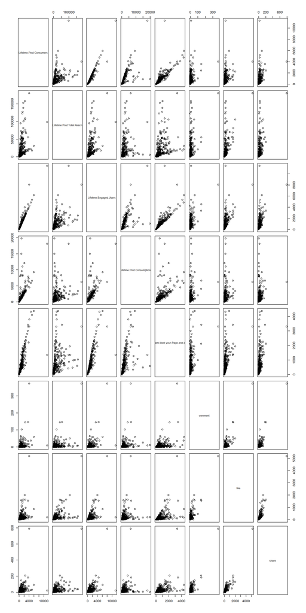

```r
pairs(fb_subset)
```

With the pairs plot, we can see it appears some relationships could be looked at, but quickly seeing the order of magnitude on the reponse variable, suggests we should also do a box-cox plot to determine if perhaps the response should be transformed.

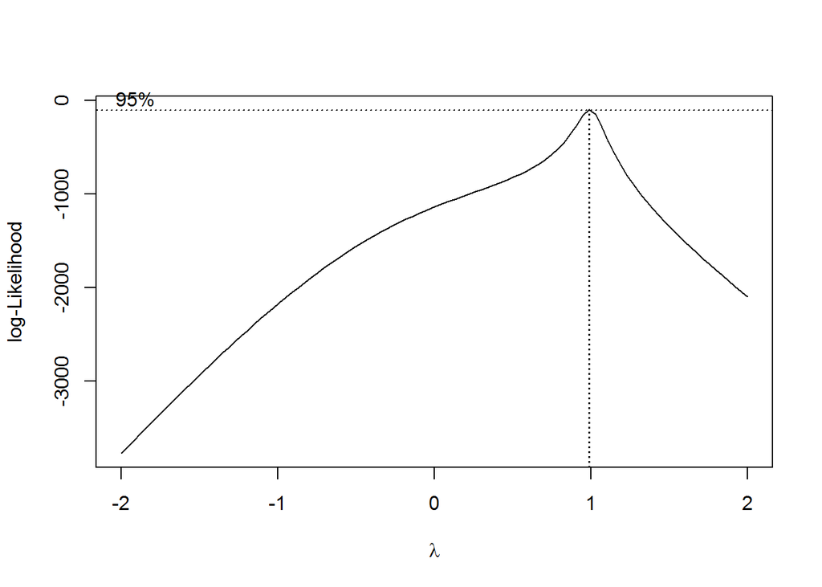

```r
boxcox(model_selected_RSS_Manual, plotit = TRUE)
```

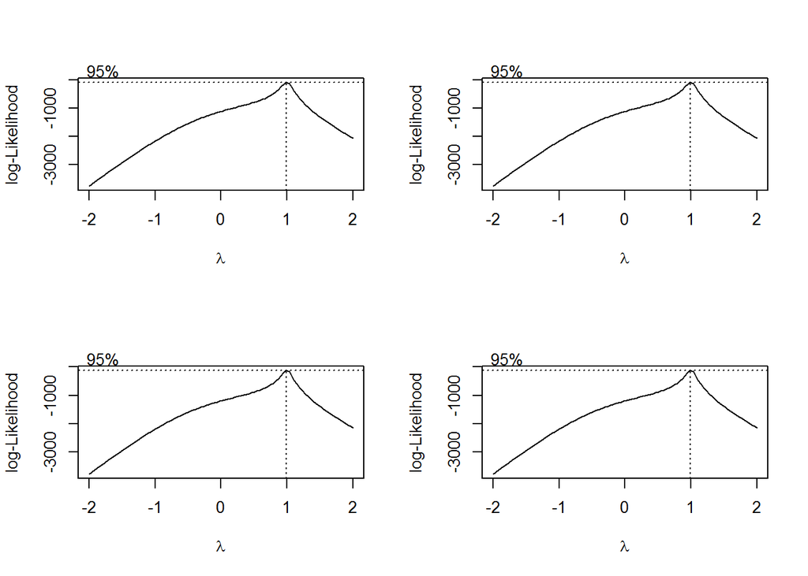

```r
par(mfrow = c(2,2))
boxcox(model_forward_aic, plotit = TRUE)
boxcox(model_back_aic, plotit = TRUE)
boxcox(model_forward_bic, plotit = TRUE)
boxcox(model_back_bic, plotit = TRUE)
```

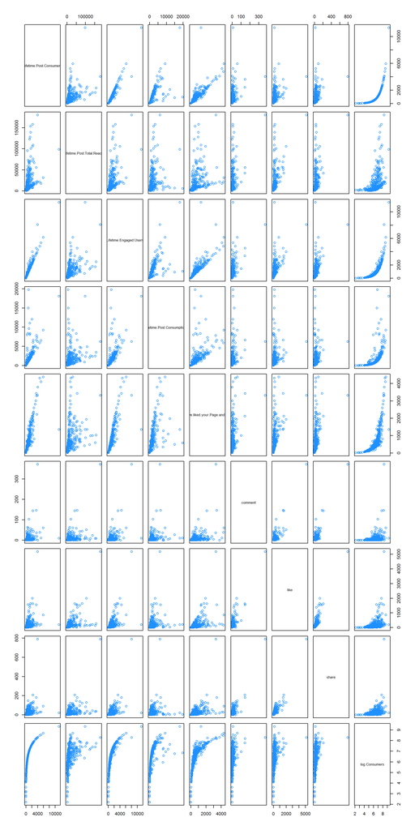

```r
fb_subset = subset(fb, select = c("Lifetime.Post.Consumers", "Lifetime.Post.Total.Reach", "Lifetime.Engaged.Users", "Lifetime.Post.Consumptions", "Lifetime.People.who.have.liked.your.Page.and.engaged.with.your.post", "comment", "like", "share"))

log.Consumers = log(fb_subset$Lifetime.Post.Consumers)

fb_withResponseTransform = cbind( fb_subset, log.Consumers)
pairs(fb_withResponseTransform, col = "dodgerblue")
```

The pairs plot shown above makes seeing a few trends much easier with the addition of the log.Consumers. Several variables appear to either require a log transformation, or perhaps a power transforation. Given we currently have 7 predictors of interest, a function was written to automate reviewing this information.

```r
min(fb_withResponseTransform$Lifetime.Post.Total.Reach)
```

```
## [1] 238
```

```r
min(fb_withResponseTransform$Lifetime.Engaged.Users)
```

```
## [1] 9
```

```r
min(fb_withResponseTransform$Lifetime.Post.Consumptions)
```

```
## [1] 9
```

```r
min(fb_withResponseTransform$Lifetime.People.who.have.liked.your.Page.and.engaged.with.your.post)
```

```
## [1] 9
```

```r
min(fb_withResponseTransform$comment)
```

```
## [1] 0
```

```r
min(fb_withResponseTransform$like)
```

```
## [1] 0
```

```r
min(fb_withResponseTransform$share)
```

```
## [1] 0
```

```r
transformationsPowers = function(predictor, response, dataset, responsevector, predictorvector){

  strQuad                      = paste("log(", response, ") ~ ", predictor , " + I(" , predictor, "^ 2) ")

  quad_model                   = lm(strQuad, data = dataset)

  quad_RMSE                    = sqrt(mean((responsevector - exp(fitted(quad_model))) ^ 2))
  quad_bp_p_value              = bptest(quad_model)$p.value
  quad_shapiro_p_value         = shapiro.test(resid(quad_model))$p.value

#  quad = c(quad_RMSE, quad_bp_p_value, quad_shapiro_p_value)

  strThird                     = paste("log(", response, ") ~ ", predictor , " + I(" , predictor, "^ 2)  + I(", predictor, "^3)")
  third_model                  = lm(strThird, data = dataset)

  third_RMSE                   = sqrt(mean((responsevector - exp(fitted(third_model))) ^ 2))
  third_bp_p_value             = bptest(third_model)$p.value
  third_shapiro_p_value        = shapiro.test(resid(third_model))$p.value

#  third = c(third_RMSE, third_bp_p_value, third_shapiro_p_value)

#  result = data.frame(log = log, quad = quad, third = third)

  predictor   = rep(predictor, 2)
  transform   = c("^2 obeying hierachy", "^3 obeying hierachy")
  bp          = c(quad_bp_p_value, third_bp_p_value)
  shapiro     = c(quad_shapiro_p_value, third_shapiro_p_value)
  RMSE        = c(quad_RMSE, third_RMSE)

  data.frame(predictor = predictor, transform = transform, bp = bp, shapiro = shapiro, RMSE = RMSE)

}

variables = colnames(fb_withResponseTransform)
predictor_variables = variables[which((variables != "Lifetime.Post.Consumers") & variables != "log.Consumers")]

length(predictor_variables)
```

```
## [1] 7
```

```r
result1 = transformationsPowers(predictor_variables[1], "Lifetime.Post.Consumers", fb_withResponseTransform, fb_withResponseTransform$Lifetime.Post.Consumers)
knitr::kable(result1, caption = "Transformation Review")
```

Transformation Review

| predictor | transform | bp | shapiro | RMSE |
| --- | --- | --- | --- | --- |
| Lifetime.Post.Total.Reach | ^2 obeying hierachy | 0.6870255 | 0 | 806.4718 |
| Lifetime.Post.Total.Reach | ^3 obeying hierachy | 0.9922775 | 0 | 841.1625 |

```r
result1 = transformationsPowers(predictor_variables[2], "Lifetime.Post.Consumers", fb_withResponseTransform, fb_withResponseTransform$Lifetime.Post.Consumers)
knitr::kable(result1, caption = "Transformation Review")
```

Transformation Review

| predictor | transform | bp | shapiro | RMSE |
| --- | --- | --- | --- | --- |
| Lifetime.Engaged.Users | ^2 obeying hierachy | 0 | 0 | 1014.5434 |
| Lifetime.Engaged.Users | ^3 obeying hierachy | 0 | 0 | 557.4647 |

```r
result1 = transformationsPowers(predictor_variables[3], "Lifetime.Post.Consumers", fb_withResponseTransform, fb_withResponseTransform$Lifetime.Post.Consumers)
knitr::kable(result1, caption = "Transformation Review")
```

Transformation Review

| predictor | transform | bp | shapiro | RMSE |
| --- | --- | --- | --- | --- |
| Lifetime.Post.Consumptions | ^2 obeying hierachy | 0 | 0 | 950.7600 |
| Lifetime.Post.Consumptions | ^3 obeying hierachy | 0 | 0 | 671.4429 |

```r
result1 = transformationsPowers(predictor_variables[4], "Lifetime.Post.Consumers", fb_withResponseTransform, fb_withResponseTransform$Lifetime.Post.Consumers)
knitr::kable(result1, caption = "Transformation Review")
```

Transformation Review

| predictor | transform | bp | shapiro | RMSE |
| --- | --- | --- | --- | --- |
| Lifetime.People.who.have.liked.your.Page.and.engaged.with.your.post | ^2 obeying hierachy | 0.0000414 | 0 | 703.3649 |
| Lifetime.People.who.have.liked.your.Page.and.engaged.with.your.post | ^3 obeying hierachy | 0.0001331 | 0 | 715.6237 |

```r
result1 = transformationsPowers(predictor_variables[5], "Lifetime.Post.Consumers", fb_withResponseTransform, fb_withResponseTransform$Lifetime.Post.Consumers)
knitr::kable(result1, caption = "Transformation Review")
```

Transformation Review

| predictor | transform | bp | shapiro | RMSE |
| --- | --- | --- | --- | --- |
| comment | ^2 obeying hierachy | 0.9160905 | 1e-07 | 920.7268 |
| comment | ^3 obeying hierachy | 0.6401742 | 1e-07 | 851.1077 |

```r
result1 = transformationsPowers(predictor_variables[6], "Lifetime.Post.Consumers", fb_withResponseTransform, fb_withResponseTransform$Lifetime.Post.Consumers)
knitr::kable(result1, caption = "Transformation Review")
```

Transformation Review

| predictor | transform | bp | shapiro | RMSE |
| --- | --- | --- | --- | --- |
| like | ^2 obeying hierachy | 0.4358813 | 3.0e-07 | 910.9140 |
| like | ^3 obeying hierachy | 0.0920669 | 1.5e-05 | 844.5598 |

```r
result1 = transformationsPowers(predictor_variables[7], "Lifetime.Post.Consumers", fb_withResponseTransform, fb_withResponseTransform$Lifetime.Post.Consumers)
knitr::kable(result1, caption = "Transformation Review")
```

Transformation Review

[output not shown]

```r
transformationsLog = function (response, predictors, dataset, responsevector){
  log_RMSE = rep(0:length(predictors))
  log_bp_p_value  = rep(0:length(predictors))
  log_shapiro_p_value  = rep(0:length(predictors))

for (i in 1: length(predictors)){

  strLog = paste("log(", response, ") ~ log(", predictors[i] , ")")

  log_model = lm(strLog, data = dataset)

  log_RMSE[i]                     = sqrt(mean((responsevector - exp(fitted(log_model))) ^ 2))
  log_bp_p_value[i]               = bptest(log_model)$p.value
  log_shapiro_p_value[i]          = shapiro.test(resid(log_model))$p.value
}

  transform = rep("log of predictor", length(predictors))
  data.frame(predictors[i], transform = "log of predictor", log_RMSE = log_RMSE, log_bp_p_value = log_bp_p_value, log_shapiro_p_value = log_shapiro_p_value)

}
```

In order to explore log transformations on predictor variables, in the case when the range is from 0 to some value, we will add 1 to the predictor variable.

```r
fb_withResponseTransformForLog = fb_withResponseTransform
fb_withResponseTransformForLog$like = fb_withResponseTransformForLog$like + 1
fb_withResponseTransformForLog$share = fb_withResponseTransformForLog$share + 1
fb_withResponseTransformForLog$comment = fb_withResponseTransformForLog$comment + 1

result1 = transformationsLog("Lifetime.Post.Consumers", predictor_variables, fb_withResponseTransformForLog, fb_withResponseTransformForLog$Lifetime.Post.Consumers )

knitr::kable(result1, caption = "Transformation Review")
```

Transformation Review

| predictors.i. | transform | log_RMSE | log_bp_p_value | log_shapiro_p_value |
| --- | --- | --- | --- | --- |
| share | log of predictor | 761.6745 | 0.9358177 | 0.0000000 |
| share | log of predictor | 221.9908 | 0.0778719 | 0.0000000 |
| share | log of predictor | 620.5757 | 0.0000000 | 0.0000000 |
| share | log of predictor | 524.1905 | 0.0823193 | 0.0000000 |
| share | log of predictor | 837.7217 | 0.0069794 | 0.0000079 |
| share | log of predictor | 824.7945 | 0.0023929 | 0.7101605 |
| share | log of predictor | 835.9544 | 0.0000023 | 0.0267167 |
| share | log of predictor | 7.0000 | 7.0000000 | 7.0000000 |